# CP05

dearbharat

6/15/2021

# Models with numerical explanatory variables

## Data: Paris Paintings

```r
pp <- read_csv("paris-paintings.csv", na = c("n/a", "", "NA"))
```

- Number of observations: 3393
- Number of variables: 61

## Goal: Predict height from width

$$\widehat{height}_{i} = \beta_0 + \beta_1 \times width_{i}$$

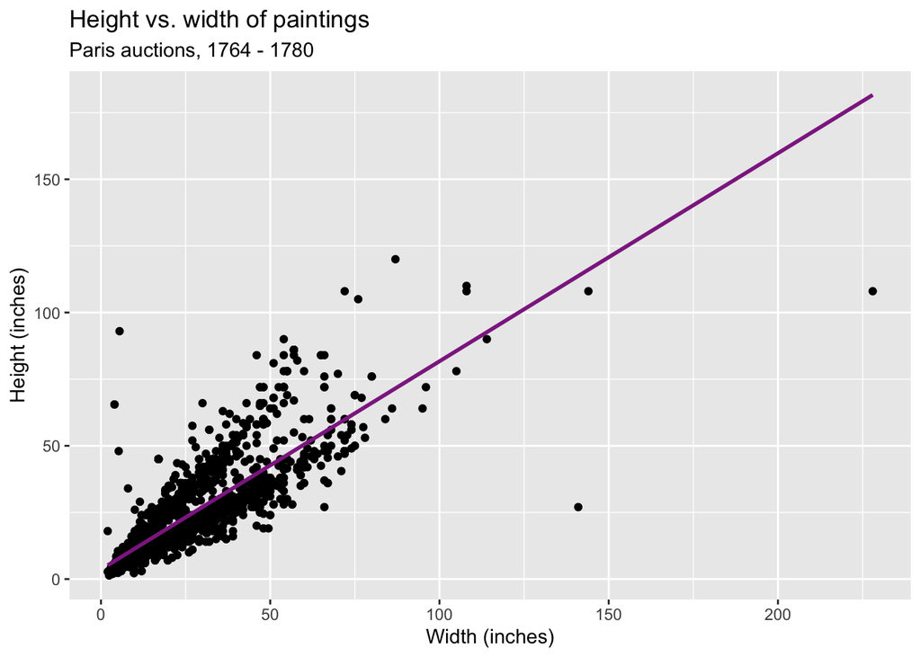

[figure not shown]

## Step 1: Specify model

```r
linear_reg()
```

```
## Linear Regression Model Specification (regression)
```

## Step 2: Set model fitting *engine*

```r
linear_reg() %>%
  set_engine("lm") # lm: linear model
```

```
## Linear Regression Model Specification (regression)
##
## Computational engine: lm
```

## Step 3: Fit model & estimate parameters

… using **formula syntax**

```r
linear_reg() %>%
  set_engine("lm") %>%
  fit(Height_in ~ Width_in, data = pp)
```

```
## parsnip model object
##
## Fit time:  3ms
##
## Call:
## stats::lm(formula = Height_in ~ Width_in, data = data)
##
## Coefficients:
## (Intercept)     Width_in
##      3.6214       0.7808
```

## A closer look at model output

```
## parsnip model object
##
## Fit time:  1ms
##
## Call:
## stats::lm(formula = Height_in ~ Width_in, data = data)
##
## Coefficients:
## (Intercept)     Width_in
##      3.6214       0.7808
```

.large[
$$\widehat{height}_{i} = 3.6214 + 0.7808 \times width_{i}$$
]

## A tidy look at model output

```r
linear_reg() %>%
  set_engine("lm") %>%
  fit(Height_in ~ Width_in, data = pp) %>%
  tidy()
```

```
## # A tibble: 2 x 5
##   term        estimate std.error statistic  p.value
##   <chr>          <dbl>     <dbl>     <dbl>    <dbl>
## 1 (Intercept)    3.62    0.254        14.3 8.82e-45
## 2 Width_in       0.781   0.00950      82.1 0
```

.large[
$$\widehat{height}_{i} = 3.62 + 0.781 \times width_{i}$$
]

## Slope and intercept

.large[
$$\widehat{height}_{i} = 3.62 + 0.781 \times width_{i}$$
]

- **Slope:** For each additional inch the painting is wider, the height is expected to be higher, on average, by 0.781 inches.

| - **Intercept:** Paintings that are 0 inches wide are expected to be 3.62 inches high, on average. (Does this make sense?) |
| --- |

## Correlation does not imply causation

Remember this when interpreting model coefficients

[figure not shown]

.footnote[ Source: XKCD, [Cell phones](https://xkcd.com/925/)]

# Parameter estimation

## Linear model with a single predictor

- We’re interested in $\beta_0$ (population parameter for the intercept) and $\beta_1$ (population parameter for the slope) in the following model:

$$\hat{y}_{i} = \beta_0 + \beta_1~x_{i}$$

| - Tough luck, you can’t have them… |
| --- |
| - So we use sample statistics to estimate them: |
| $$\hat{y}_{i} = b_0 + b_1~x_{i}$$ |

## Least squares regression

- The regression line minimizes the sum of squared residuals.

| - If $e_i = y_i - \hat{y}_i$, then, the regression line minimizes $\sum_{i = 1}^n e_i^2$. |
| --- |

## Visualizing residuals

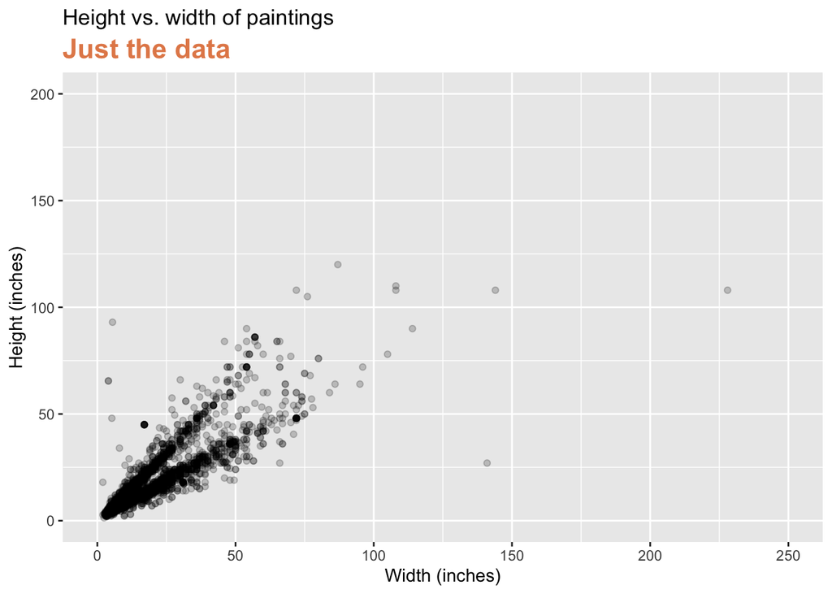

## Visualizing residuals (cont.)

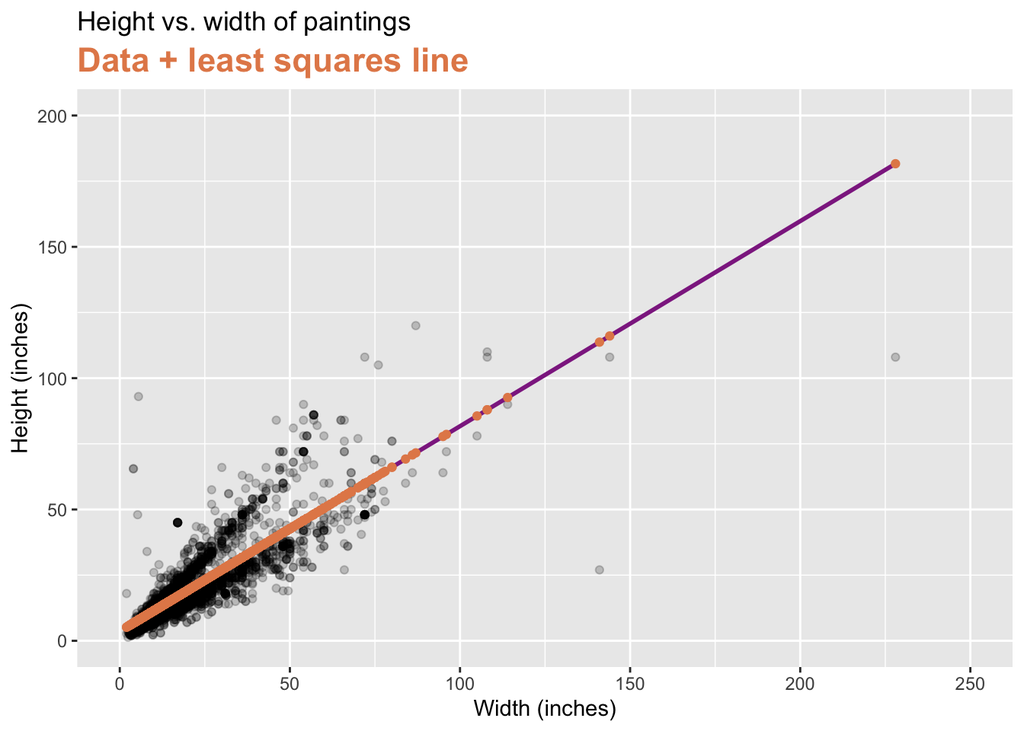

## Visualizing residuals (cont.)

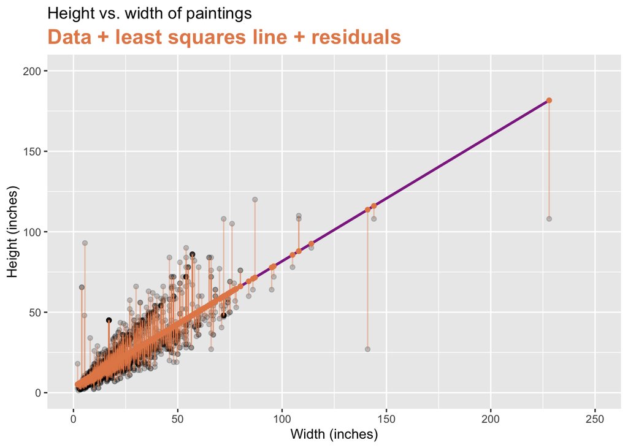

## Properties of least squares regression

- The regression line goes through the center of mass point, the coordinates corresponding to average $x$ and average $y$, $(\bar{x}, \bar{y})$:

$$\bar{y} = b_0 + b_1 \bar{x} ~ \rightarrow ~ b_0 = \bar{y} - b_1 \bar{x}$$

| - The slope has the same sign as the correlation coefficient: $b_1 = r \frac{s_y}{s_x}$ |
| --- |
| - The sum of the residuals is zero: $\sum_{i = 1}^n e_i = 0$ |

- The residuals and $x$ values are uncorrelated

# Models with categorical explanatory variables

## Categorical predictor with 2 levels

```
## # A tibble: 3,393 x 3
##    name      Height_in landsALL
##    <chr>         <dbl>    <dbl>
##  1 L1764-2          37        0
##  2 L1764-3          18        0
##  3 L1764-4          13        1
##  4 L1764-5a         14        1
##  5 L1764-5b         14        1
##  6 L1764-6           7        0
##  7 L1764-7a          6        0
##  8 L1764-7b          6        0
##  9 L1764-8          15        0
## 10 L1764-9a          9        0
## 11 L1764-9b          9        0
## 12 L1764-10a        16        1
## 13 L1764-10b        16        1
## 14 L1764-10c        16        1
## 15 L1764-11         20        0
## 16 L1764-12a        14        1
## 17 L1764-12b        14        1
## 18 L1764-13a        15        1
## 19 L1764-13b        15        1
## 20 L1764-14         37        0
## # … with 3,373 more rows
```

## Height & landscape features

```r
linear_reg() %>%
  set_engine("lm") %>%
  fit(Height_in ~ factor(landsALL), data = pp) %>%
  tidy()
```

```
## # A tibble: 2 x 5
##   term              estimate std.error statistic  p.value
##   <chr>                <dbl>     <dbl>     <dbl>    <dbl>
## 1 (Intercept)          22.7      0.328      69.1 0
## 2 factor(landsALL)1    -5.65     0.532     -10.6 7.97e-26
```

## Height & landscape features

$$\widehat{Height_{in}} = 22.7 - 5.645~landsALL$$

- **Slope:** Paintings with landscape features are expected, on average, to be 5.645 inches shorter than paintings that without landscape features
  - Compares baseline level (`landsALL = 0`) to the other level (`landsALL = 1`)
- **Intercept:** Paintings that don’t have landscape features are expected, on average, to be 22.7 inches tall

## Relationship between height and school

```r
linear_reg() %>%
  set_engine("lm") %>%
  fit(Height_in ~ school_pntg, data = pp) %>%
  tidy()
```

```
## # A tibble: 7 x 5
##   term            estimate std.error statistic p.value
##   <chr>              <dbl>     <dbl>     <dbl>   <dbl>
## 1 (Intercept)        14.0       10.0     1.40  0.162
## 2 school_pntgD/FL     2.33      10.0     0.232 0.816
## 3 school_pntgF       10.2       10.0     1.02  0.309
## 4 school_pntgG        1.65      11.9     0.139 0.889
## 5 school_pntgI       10.3       10.0     1.02  0.306
## 6 school_pntgS       30.4       11.4     2.68  0.00744
## 7 school_pntgX        2.87      10.3     0.279 0.780
```

## Dummy variables

```
## # A tibble: 7 x 5
##   term            estimate std.error statistic p.value
##   <chr>              <dbl>     <dbl>     <dbl>   <dbl>
## 1 (Intercept)        14.0       10.0     1.40  0.162
## 2 school_pntgD/FL     2.33      10.0     0.232 0.816
## 3 school_pntgF       10.2       10.0     1.02  0.309
## 4 school_pntgG        1.65      11.9     0.139 0.889
## 5 school_pntgI       10.3       10.0     1.02  0.306
## 6 school_pntgS       30.4       11.4     2.68  0.00744
## 7 school_pntgX        2.87      10.3     0.279 0.780
```

- When the categorical explanatory variable has many levels, they’re encoded to **dummy variables**
- Each coefficient describes the expected difference between heights in that particular school compared to the baseline level

## Categorical predictor with 3+ levels

| school_pntg | D_FL | F | G | I | S | X |
| --- | --- | --- | --- | --- | --- | --- |
| A | 0 | 0 | 0 | 0 | 0 | 0 |
| D/FL | 1 | 0 | 0 | 0 | 0 | 0 |
| F | 0 | 1 | 0 | 0 | 0 | 0 |
| G | 0 | 0 | 1 | 0 | 0 | 0 |
| I | 0 | 0 | 0 | 1 | 0 | 0 |
| S | 0 | 0 | 0 | 0 | 1 | 0 |
| X | 0 | 0 | 0 | 0 | 0 | 1 |

```
## # A tibble: 3,393 x 3
##    name      Height_in school_pntg
##    <chr>         <dbl> <chr>
##  1 L1764-2          37 F
##  2 L1764-3          18 I
##  3 L1764-4          13 D/FL
##  4 L1764-5a         14 F
##  5 L1764-5b         14 F
##  6 L1764-6           7 I
##  7 L1764-7a          6 F
##  8 L1764-7b          6 F
##  9 L1764-8          15 I
## 10 L1764-9a          9 D/FL
## 11 L1764-9b          9 D/FL
## 12 L1764-10a        16 X
## 13 L1764-10b        16 X
## 14 L1764-10c        16 X
## 15 L1764-11         20 D/FL
## 16 L1764-12a        14 D/FL
## 17 L1764-12b        14 D/FL
## 18 L1764-13a        15 D/FL
## 19 L1764-13b        15 D/FL
## 20 L1764-14         37 F
## # … with 3,373 more rows
```

## Relationship between height and school

```
## # A tibble: 7 x 5
##   term            estimate std.error statistic p.value
##   <chr>              <dbl>     <dbl>     <dbl>   <dbl>
## 1 (Intercept)        14.0       10.0     1.40  0.162
## 2 school_pntgD/FL     2.33      10.0     0.232 0.816
## 3 school_pntgF       10.2       10.0     1.02  0.309
## 4 school_pntgG        1.65      11.9     0.139 0.889
## 5 school_pntgI       10.3       10.0     1.02  0.306
## 6 school_pntgS       30.4       11.4     2.68  0.00744
## 7 school_pntgX        2.87      10.3     0.279 0.780
```

- **Austrian school (A)** paintings are expected, on average, to be **14 inches** tall.
- **Dutch/Flemish school (D/FL)** paintings are expected, on average, to be **2.33 inches taller** than *Austrian school* paintings.
- **French school (F)** paintings are expected, on average, to be **10.2 inches taller** than *Austrian school* paintings.
- **German school (G)** paintings are expected, on average, to be **1.65 inches taller** than *Austrian school* paintings.
- **Italian school (I)** paintings are expected, on average, to be **10.3 inches taller** than *Austrian school* paintings.
- **Spanish school (S)** paintings are expected, on average, to be **30.4 inches taller** than *Austrian school* paintings.
- Paintings whose school is **unknown (X)** are expected, on average, to be **2.87 inches taller** than *Austrian school* paintings. ]